# Time Series Modeling and Forecasting: An Exploration of Electricity Use in Macalester’s Eco House

Author

Katelyn McClure and Lilabeth Sokolewicz

Published

October 9, 2025

Abstract

## Introduction

Electricity powers much of our home, work, and entertainment, including lighting, temperature regulation, and cooking systems. Its use also has significant economic and environmental impact. According to the Environmental Center at the University of Colorado Boulder, about a quarter of greenhouse gas emissions in the United States come from electricity generation (2023). For instance, commercial buildings consume 19% of the United States’ energy and produce 1.0 billion metric tons of carbon dioxide annually (Jafary et al. 2016). Beyond environmental concerns, there is economic benefit to limiting energy consumption – higher education institutions in the US spend about $1.10 per square foot on electricity (Jafary et al. 2016). Therefore, reducing electricity use can be a tangible way for an institution to make an impact on their emissions and their budget.

College campuses differ from other commercial or residential complexes in that they contain many different types of buildings, used for academic, athletics, residential, parking, and more. They are also distinct in that their occupancy and use varies seasonally with the academic calendar. Most campuses house fewer staff and students over the weekends, summer months, and holidays, unlike most residential and commercial buildings (Nasir 2023). A recent study produced neural network machine learning models that predicted the 2024 energy usage of the University of Missouri with 98% accuracy, using seven years of hourly data and accounting for seasonal and time-of-day variability (Alsamraee and Khanna 2025). All tested models performed well, highlighting the strong and true seasonality of college energy data.

Colleges thus present a unique opportunity to test innovative energy-saving and eco-conscious practices - in fact, some schools, like Macalester College in Saint Paul, have buildings dedicated to this purpoese. Macalester’s Eco House is a one-floor, detached residence that houses 4 students each year. It is designated to test renovations and green technologies, such as using solar heated water. By identifying trends, exploring variations, and forecasting electricity usage accurately, we aim to help Macalester understand the electricity use of the Eco House in order to better work towards their sustainability goals.

## Data

The data used in the report was provided by the Macalester College Sustainability Office. It was collected from Macalester-owned properties’ electricity meters, as a usage amount between the start and end of a month. There are three types of electricity meters: grid, solar, and wind.

The most important variable to this analysis is `use_per_day`, which measures the average electricity usage per day within the collection period. Since the data was collected monthly, the use per month was divided by the days in the collection period to get the average use per day. We also use `start_date` as a measure of time, from which we extract month and year variables. The data for this report was first collected June 1st, 2013, and last collected January 31st, 2025.

We chose to focus on the meter representing Macalester’s Eco House, so, for our analysis, we filtered the dataset to contain only data from that meter, which uses grid power.

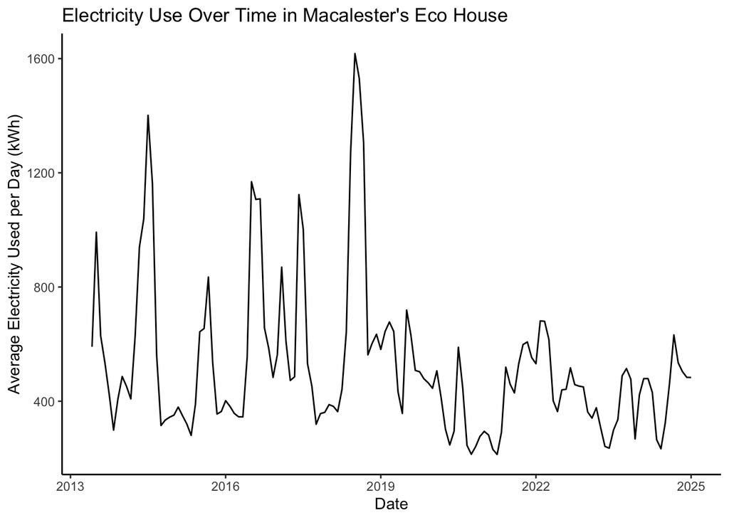

From this plot, we can see that average electricity use per day peaks between 2018 and 2019, with smaller highs in preceding years. It appears to follow a seasonal pattern, with a visible pattern of peaks and dips repeating over the course of each year. Beginning in 2020, the year of the pandemic, and continuing through 2025, overall average electricity use is considerably smaller than its pre-pandemic levels.

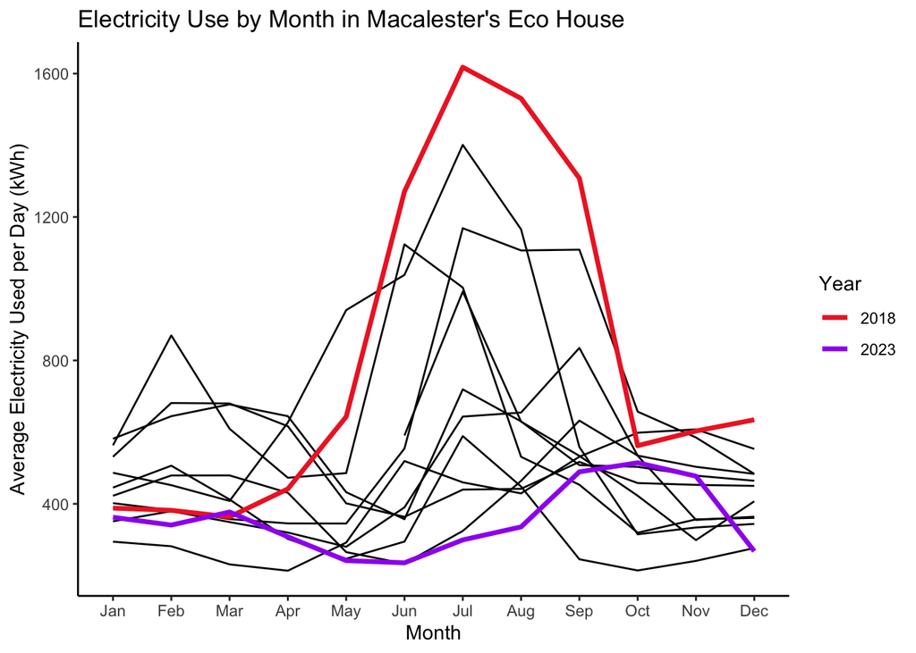

## Methods

In order to estimate the overall trend of electricity use over time, we used B-spline regression (Boor 1978). This parametric approach, a smooth, piecewise polynomial, with breaks at specified knots along the x-axis, is used to handle nonlinear relationships. It provides a flexible, smooth trend estimation without overfitting. The chosen knots (2019, 2021, 2023) correspond to period of known and observed change in electricity use, such as the COVID-19 pandemic.

We obtained seasonality estimates by fitting a linear regression model on the detrended `use_per_day`, with month as the independent variable. A linear regression model allowed us to model seasonal patterns by fitting a separate intercept for each month, capturing average monthly deviations without assuming a parametric pattern.

Having removed trend and seasonality from our data, we needed to model the correlation in the residuals. In order to select a model, we examined plots of the autocorrelation function (ACF), which shows estimates of the autocorrelation at each lag, and partial autocorrelation function (PACF), which shows the autocorrelation at each lag with the linear dependence removed. For our random errors, the ACF appeared to decay to zero and the PACF seemed to drop to zero after lag 2; therefore, we chose to fit the following models:

Finally, we used our estimated trend, seasonality, and errors in order to forecast `use_per_day` for the 24 months immediately following the data collection period. We created a matrix of variables for the trend and seasonality of our original data, a matrix of those predictor variables for times in the future, and passed them to the `sarima.for()` function, which provides forecasts (and their standard errors) for a specified number of time points ahead for a specified ARMA model (Stoffer and Poison 2025). Forecasts were then visualized with their confidence intervals.

All analyses were completed in R, using the following packages:

- tidyverse for data wrangling and visualization (Wickham et al. 2019).
- splines for B-spline fitting (Douglas and Venables 2025)
- astsa for diagnostics and forecasting (Stoffer and Poison 2025).

## Results

The long-term trend and seasonal components of daily electricity usage were first modeled using a B-spline function with knots at 2019, 2021, and 2023, shown below in red, along with month as a categorical factor to account for recurring seasonal variation, shown in purple.

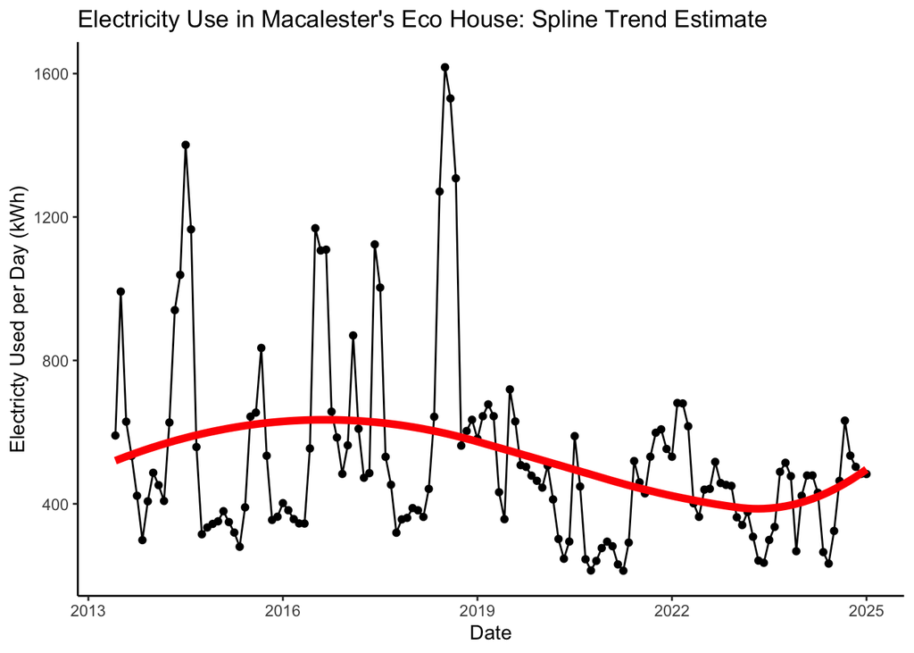

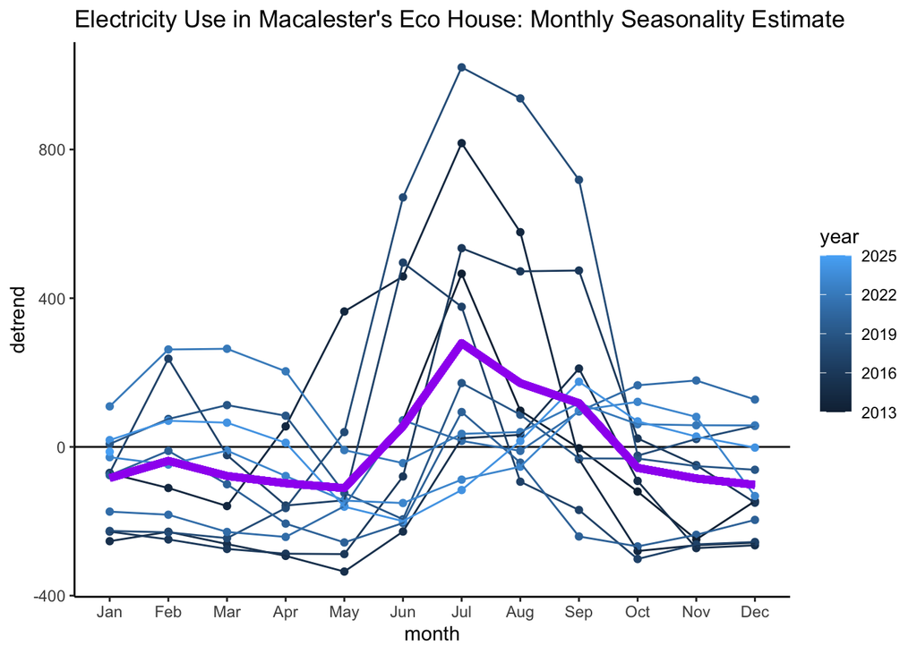

|  | AIC | BIC | mean.LjungBox.p.value |
| --- | --- | --- | --- |
| AR(1) | 1795.690 | 1804.515 | 0.0405518 |
| AR(2) | 1779.093 | 1790.859 | 0.8661236 |
| MA(2) | 1787.830 | 1799.597 | 0.2128807 |
| ARMA(2, 2) | 1776.621 | 1794.271 | 0.9250397 |

We decided to use an AR(2) model because of it’s relatively low BIC value of 1790.859 and it’s relatively high mean Ljung-Box p-value of 0.8661236. While the ARMA(2, 2) model performs similarly, we chose the simpler model for parsimony.

Diagnostic plots showed residuals centered around zero with no clear temporal structure, confirming that the trend and seasonality components were effectively removed.

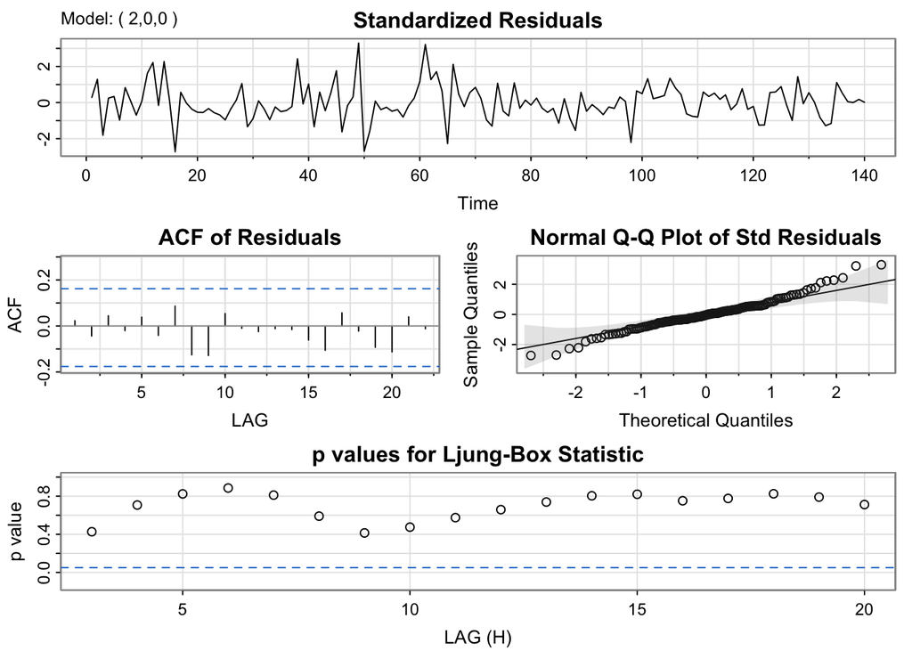

Using the selected AR(2) model, forecasts were generated for the next 24 months (January 2025–December 2026).

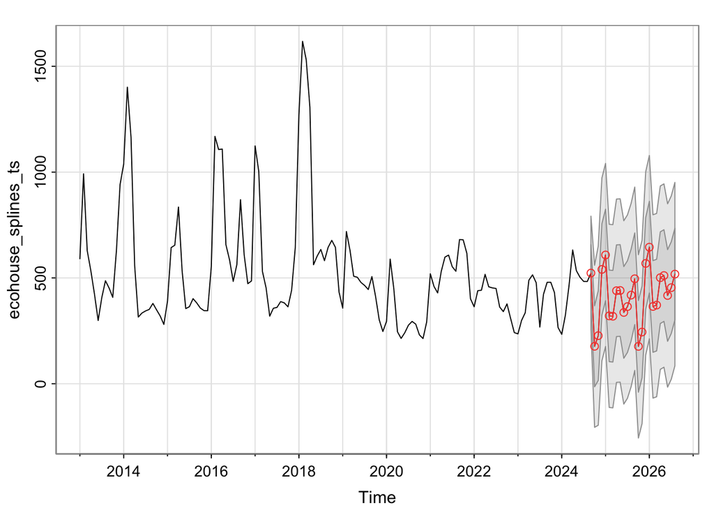

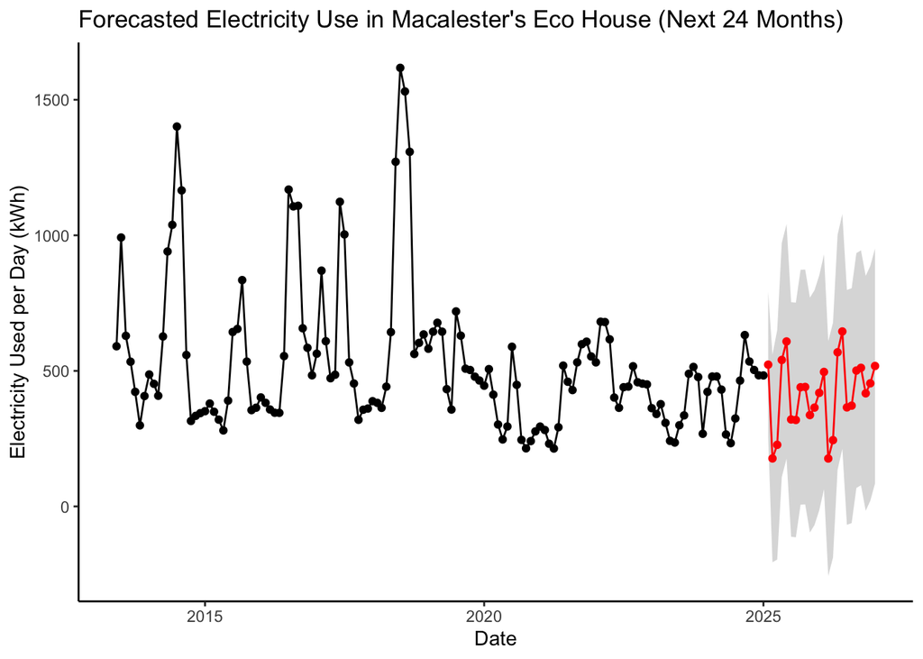

Predicted values ranged from approximately 200 to 700 kWh per day, following a recurring seasonal cycle of summer peaks and winter lows. Our confidence intervals reveal that there is great uncertainty in our model, as each point has about a 500 kWh 95% confidence interval surrounding it.

## Conclusions

After removing these trend and seasonal effects, an AR(2) model best described the remaining residual structure based on BIC values and Ljung–Box tests. This model accounted for short-term dependencies without unnecessary complexity, suggesting that most systematic variation in the data was successfully captured. The 24-month forecast indicated stable future electricity use with recurring seasonal fluctuations and no substantial long-term changes.

While these results are encouraging, the model has several limitations. It relies solely on time-based predictors, excluding potentially influential factors such as temperature, number of residents, or appliance upgrades. The assumption of consistent behavior across years also limits interpretability, as new students move into the Eco House each school year. Incorporating these external variables could improve model accuracy and better explain observed changes.

In a broader context, this study demonstrates how time series modeling can contribute to sustainability monitoring. Understanding the timing and magnitude of consumption patterns can help guide energy-saving initiatives, evaluate the impact of efficiency programs, and inform future sustainability planning for campus buildings, including student housing.

## Acknowledgements

Thank you to Dr. Brianna Heggeseth for teaching STAT452 at Macalester and for preparing neat and detailed class activity and project templates. And a special thank you to the students who attended Brianna’s office hours on Monday and convinced her to push the deadline back to Thursday.

## References

Alsamraee, Saad A., and Sanjeev Khanna. 2025. “Long-Term Electricity Demand Forecasting of a University Campus Based on Advanced Deep Learning Artificial Neural Network Algorithms.” *Results in Engineering* 27. https://doi.org/10.1016/j.rineng.2025.106683.

Boor, C. de. 1978. *A Practical Guide to Splines*. Springer New York, NY.

Douglas, B. M., and W. N. Venables. 2025. *Regression Spline Functions and Classes*.

“Empowering College Students: The Vital Role of Energy Conservation in Shaping a Sustainable Future.” 2023. https://www.colorado.edu/ecenter/2023/12/12/empowering-college-students-vital-role-energy-conservation-shaping-sustainable-future.

Jafary, M., M. Wright, L. Shephard, J. Gomez, and R. Unnikrishnan Nair. 2016. “Understanding Campus Energy Consumption – People, Buildings and Technology.” In *2016 IEEE Green Technologies Conference (GreenTech)*, 68–72. https://doi.org/10.1109/GreenTech.2016.20.

Ljung, G. M., and G. E. P. Box. 1978. “On a Measure of Lack of Fit in Time Series Models.” *Biometrika* 65 (2): 297–303. http://www.jstor.org/stable/2335207.

Nasir, Ludin, S. N. S. 2023. “Lockdown Impact on Energy Consumption in University Building.” *Environment, Development, and Sustainability* 25: 12051–70. https://doi.org/10.1007/s10668-022-02507-z.

Schwarz, G. 1978. “Estimating the Dimension of a Model.” *The Annals of Statistics*, no. 2: 461–64. https://doi.org/10.1214/aos/1176344136.

Stoffer, D., and N. Poison. 2025. *Applied Statistical Time Series Analysis*. https://github.com/nickpoison/astsa/blob/master/README.md.

Wickham, Hadley, Mara Averick, Jennifer Bryan, Winston Chang, Lucy D’Agostino McGowan, Romain François, Garrett Grolemund, et al. 2019. “Welcome to the Tidyverse.” *Journal of Open Source Software* 4 (43): 1686. https://doi.org/10.21105/joss.01686.